# Saqrlab Reference — Missing-data mechanisms

This reference covers `inject_missingness()`, a *transformer* that takes a complete data frame and injects `NA`s under a chosen missingness mechanism from the Rubin taxonomy — MCAR (completely at random), MAR (at random, driven by an observed predictor), and MNAR (not at random, driven by the missing value itself). The returned object carries a `"missing_info"` attribute recording exactly which cells were made missing.

## `inject_missingness()`

Inject missing values into target columns under a known mechanism. MAR requires an observed `predictor` column (which is itself never made missing); MNAR sets larger numeric values missing more often. All three mechanisms are calibrated so the realized missing fraction is approximately `prop`.

**Signature**

```r
args(inject_missingness)
```

```
#> function (data, mechanism = c("MCAR", "MAR", "MNAR"), prop = 0.1,
#>     cols = NULL, predictor = NULL, seed = NULL)
#> NULL
```

We start from a small complete data frame with a regression structure so that `x1` can serve as a MAR predictor of `y`.

```r
df <- simulate_prediction(
  n = 500,
  coefs = c("(Intercept)" = 1, x1 = 2, x2 = -1),
  seed = 1
)$data
head(df)
```

|  | y | x1 | x2 |
| --- | --- | --- | --- |
| 1 | 0.8047543 | -0.6264538 | 0.07730312 |
| 2 | 2.7760871 | 0.1836433 | -0.29686864 |
| 3 | -0.3587926 | -0.8356286 | -1.18324224 |
| 4 | 4.3900005 | 1.5952808 | 0.01129269 |
| 5 | 0.7368102 | 0.3295078 | 0.99160104 |
| 6 | -3.8975531 | -0.8204684 | 1.59396745 |

```r
colSums(is.na(df))   # no missingness yet
```

```
#>  y x1 x2
#>  0  0  0
```

**MCAR — missing completely at random**

Every cell of the target columns is independently set missing with probability `prop`.

```r
mcar <- inject_missingness(df, mechanism = "MCAR", prop = 0.2, seed = 7)
colSums(is.na(mcar))
```

```
#>   y  x1  x2
#>  96 104 108
```

```r
attr(mcar, "missing_info")$realized_prop
```

```
#> [1] 0.2053333
```

```r
str(attr(mcar, "missing_info"), max.level = 1)
```

```
#> List of 6
#>  $ mechanism    : chr "MCAR"
#>  $ prop         : num 0.2
#>  $ cols         : chr [1:3] "y" "x1" "x2"
#>  $ n_missing    : int 308
#>  $ realized_prop: num 0.205
#>  $ indicator    : logi [1:500, 1:3] FALSE FALSE TRUE TRUE FALSE FALSE ...
#>   ..- attr(*, "dimnames")=List of 2
```

**MAR — missing at random (driven by observed `x1`)**

Here only `y` is targeted, and its missingness probability depends on the *observed* predictor `x1` — never on `y`’s own value.

```r
mar <- inject_missingness(df, mechanism = "MAR", prop = 0.2,
                          cols = "y", predictor = "x1", seed = 7)
colSums(is.na(mar))
```

```
#>  y x1 x2
#> 96  0  0
```

```r
attr(mar, "missing_info")$realized_prop
```

```
#> [1] 0.192
```

The dependence on the predictor is visible: rows with missing `y` have a systematically different mean `x1` than rows with observed `y`.

```r
miss_y <- is.na(mar$y)
tapply(df$x1, ifelse(miss_y, "y missing", "y observed"), mean)
```

```
#>  y missing y observed
#>  0.7204732 -0.1431767
```

**MNAR — missing not at random (driven by `y` itself)**

The probability that `y` is missing depends on `y`’s own (latent) value: larger values are more likely to go missing.

```r
mnar <- inject_missingness(df, mechanism = "MNAR", prop = 0.2,
                           cols = "y", seed = 7)
colSums(is.na(mnar))
```

```
#>  y x1 x2
#> 92  0  0
```

```r
attr(mnar, "missing_info")$realized_prop
```

```
#> [1] 0.184
```

The MNAR signature: the *observed* (non-missing) `y` mean is shifted relative to the full-data mean, because the largest values were preferentially removed.

```r
c(full_mean     = mean(df$y),
  observed_mean = mean(mnar$y, na.rm = TRUE))
```

```
#>     full_mean observed_mean
#>     1.0882401     0.6747463
```

## Visualising the missingness pattern

An `image()` of the missing-cell indicator shows where the `NA`s landed. Under MCAR they scatter uniformly across all columns; under MAR/MNAR they concentrate in the single targeted column `y`.

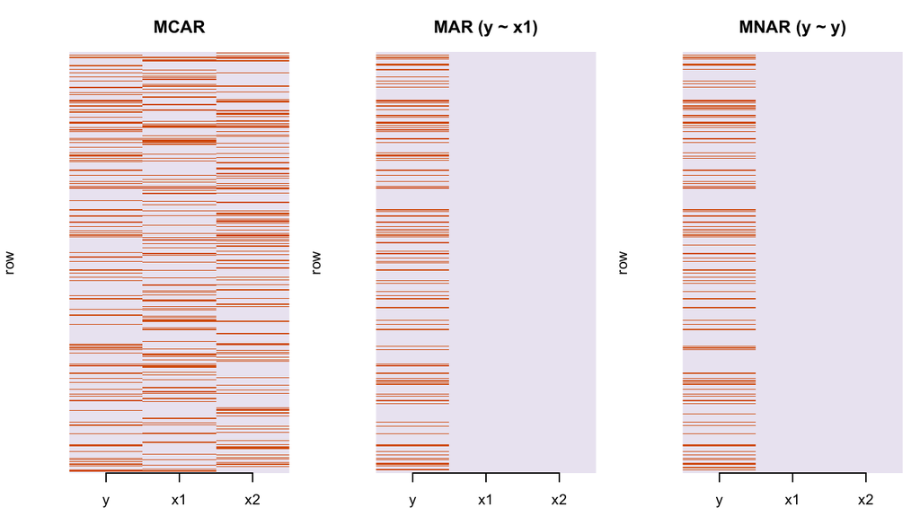

```r
op <- par(mfrow = c(1, 3), mar = c(3, 4, 3, 1))
show_pattern <- function(x, ttl) {
  m <- is.na(x[, c("y", "x1", "x2")])
  image(seq_len(ncol(m)), seq_len(nrow(m)), t(m),
        col = c("#ece7f2", "#d95f0e"), axes = FALSE,
        xlab = "", ylab = "row", main = ttl)
  axis(1, at = seq_len(ncol(m)), labels = colnames(m))
}
show_pattern(mcar, "MCAR")
show_pattern(mar,  "MAR (y ~ x1)")
show_pattern(mnar, "MNAR (y ~ y)")
```

```r
par(op)
```